# Intelligibility among Vocabularies of the EU Languages

Jacek Pardyak

5 september 2018

## Introduction

**Clustering European Languages**

In the European Union there are 24 official languages spoken among 28 member states. The EU asserts that it is in favor of linguistic diversity. This principle is a basis of many studies on mutual intelligibility between languages. Relationship between languages in which speakers can readily understand each other without prior familiarity or special effort can be measured with distance function:

$$d(V_1, V_2) = 1 - \frac{\left\vert {V_1\cap V_2}\right\vert}{\left\vert {V_1\cup V_2}\right\vert}$$

For our analysis vocabularies (V) are derived from http://hunspell.github.io/ spell checker project. For Finnish and Maltese vocabularies are not available. We perform a Hierarchical Cluster Analysis (HCA) using a set of dissimilarities for the 22 vocabularies being clustered. Pictures present results of HCA after applying different linkage criteria.

```r
#mDist2 = 1 - mDist2
#mDist2 = (1/(mDist2+0.001)) - 1
#mDist2 = as.dist(mDist2)
#mDist2
```

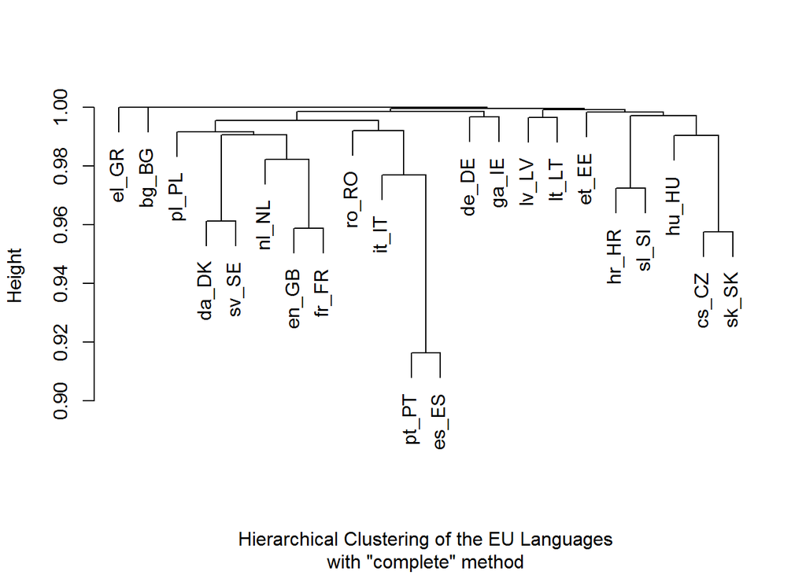

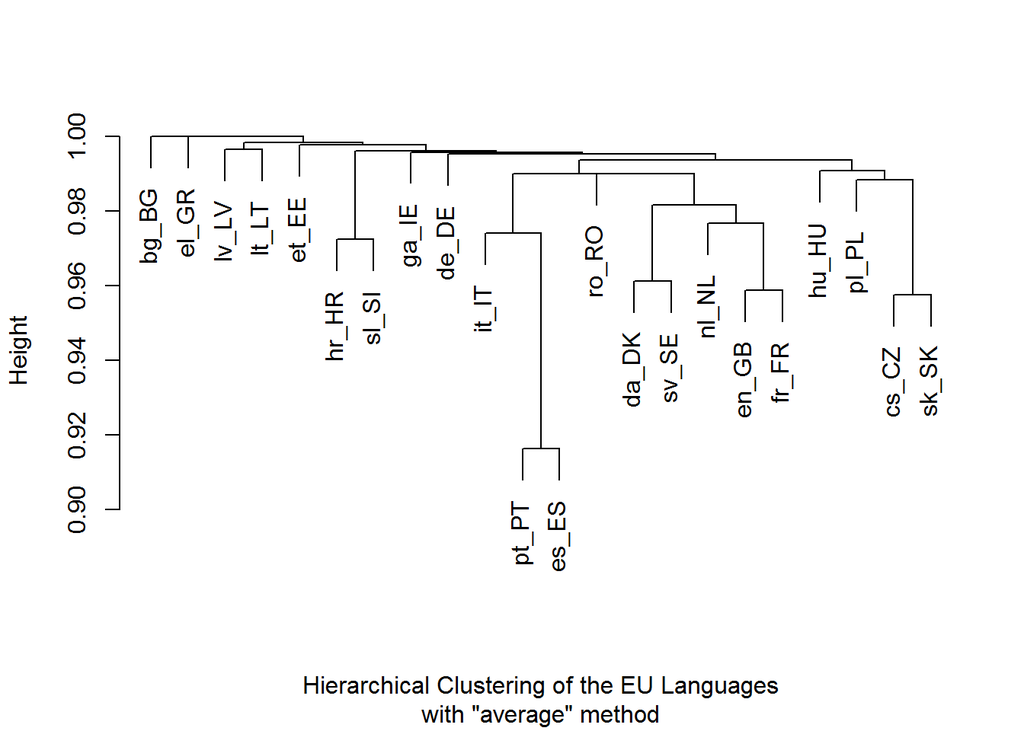

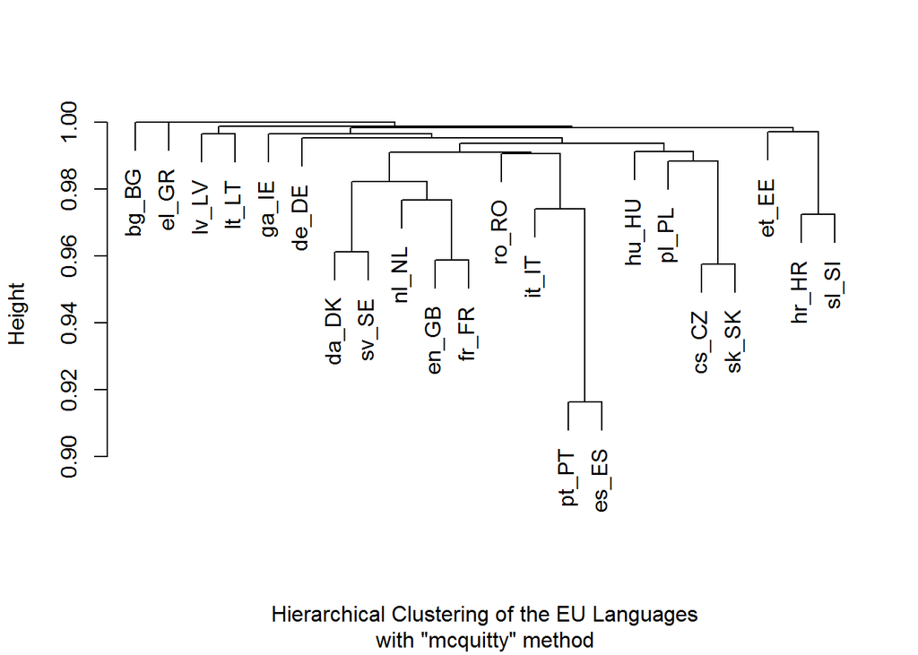

The two observations are interesting:

- HCA reveals existance of slavic languages family (pl_PL, cs_CZ, sk_SK)
- Saying that Dutch is just a mixture between English and German is terribly inaccurate.

```r
mDF <- as.matrix(mDist)
pl_PL <- mDF[, 'pl_PL']
pl_PL[order(pl_PL, decreasing = FALSE)]
```

```
##     pl_PL     en_GB     cs_CZ     da_DK     nl_NL     it_IT     sk_SK
## 0.0000000 0.9831523 0.9858495 0.9887899 0.9891335 0.9896010 0.9909898
##     sv_SE     fr_FR     hu_HU     sl_SI     es_ES     pt_PT     hr_HR
## 0.9912803 0.9916465 0.9923224 0.9923790 0.9943816 0.9944366 0.9946607
##     ro_RO     de_DE     ga_IE     et_EE     lt_LT     lv_LV     bg_BG
## 0.9955553 0.9956825 0.9958644 0.9974506 0.9974988 0.9987256 1.0000000
##     el_GR
## 1.0000000
```

```r
nl_NL <- mDF[, 'nl_NL']
nl_NL[order(nl_NL, decreasing = FALSE)]
```

```
##     nl_NL     en_GB     da_DK     fr_FR     sv_SE     pl_PL     it_IT
## 0.0000000 0.9713650 0.9807028 0.9822716 0.9866061 0.9891335 0.9909306
##     de_DE     cs_CZ     hu_HU     es_ES     ro_RO     sk_SK     pt_PT
## 0.9930614 0.9935128 0.9942315 0.9943269 0.9944476 0.9949912 0.9950583
##     sl_SI     et_EE     ga_IE     hr_HR     lt_LT     lv_LV     bg_BG
## 0.9955910 0.9959729 0.9964418 0.9973061 0.9985107 0.9988675 1.0000000
##     el_GR
## 1.0000000
```

```r
en_GB <- mDF[, 'en_GB']
en_GB[order(en_GB, decreasing = FALSE)]
```

```
##     en_GB     fr_FR     nl_NL     sv_SE     da_DK     pt_PT     ro_RO
## 0.0000000 0.9588505 0.9713650 0.9726686 0.9729823 0.9792359 0.9797630
##     it_IT     pl_PL     es_ES     ga_IE     hu_HU     de_DE     cs_CZ
## 0.9824334 0.9831523 0.9842237 0.9865805 0.9885161 0.9896744 0.9908230
##     sk_SK     sl_SI     et_EE     hr_HR     lt_LT     lv_LV     bg_BG
## 0.9932135 0.9937559 0.9970013 0.9971163 0.9975549 0.9986451 1.0000000
##     el_GR
## 1.0000000
```

There are two limitations of this approach:

- we count words in two vocabularies that look the same, but differ significantly in meaning (false friends). For example: ‘hak’ (pl_PL) - ‘hook’ (en_GB) but ‘hak’ (nl_NL) - ‘heel’ (en_GB)
- we don’t count words in two vocabularies that look similar and mean the same. For example: ‘banan’(pl_PL) - ‘banaan’(nl_NL) - ‘banana’(en_GB)

In the next article I will present hierarchical cluster analysis using ‘partial word match’ instead of ‘exact word match’.

## Definitions

**alphabet** - set of letters

**word** ($w$) - sequence of elements from an alphabet

**vocabulary** ($V$) - set of words

**words similarity** - two words $x$ and $y$ are similar if $d(x, y) \leq \epsilon$ with regard to predetermined distance $d(x,y)$ and threshold $\epsilon$.

**common vocabulary** - for two vocabularies $V_1$ and $V_2$ elements of two subsets $\overline{V_1} \subseteq V_1$ and $\overline{V_2} \subseteq V_2$ meet criterion:

$$\forall {x \in \overline{V_1}} \exists {y \in \overline{V_2} } : d(x, y) \leq \epsilon$$

**distance between vocabularies** - ratio of cardinality $\overline V_1 \cup \overline V_2$ and cardinality of $V_1 \cup V_2$. More precisely:

$$d(V_1, V_2) = 1 - \frac{\left\vert {\overline{V_1}\cup \overline{V_2}}\right\vert}{\left\vert {V_1\cup V_2}\right\vert}$$

In the special case of distance defined as $d(x,y) = 0$ if $x = y$, and $1$ otherwise and threshold $\epsilon = 0$, (perfect match) we get
$$d(V_1, V_2) = 1 - \frac{\left\vert {V_1\cap V_2}\right\vert}{\left\vert {V_1\cup V_2}\right\vert}$$

## The data

The EU has 24 official languages used by people within 28 member states. Vocabularies were retrieved from ftp://ftp.snt.utwente.nl/pub/software/openoffice/contrib/dictionaries/, part of Hunspell project http://hunspell.github.io/. Two of 24 official EU languages, Finnish and Maltese don’t have available vocabularies. We use ISO 639-2 codes of those 22 languages: bg_BG, hr_HR, cs_CZ, da_DK, nl_NL, en_GB, et_EE, fr_FR, de_DE, el_GR, hu_HU, ga_IE, it_IT, lv_LV, lt_LT, pl_PL, pt_PT, ro_RO, sk_SK, sl_SI, es_ES, sv_SE.

## Clustering vocabularies using exact word matching

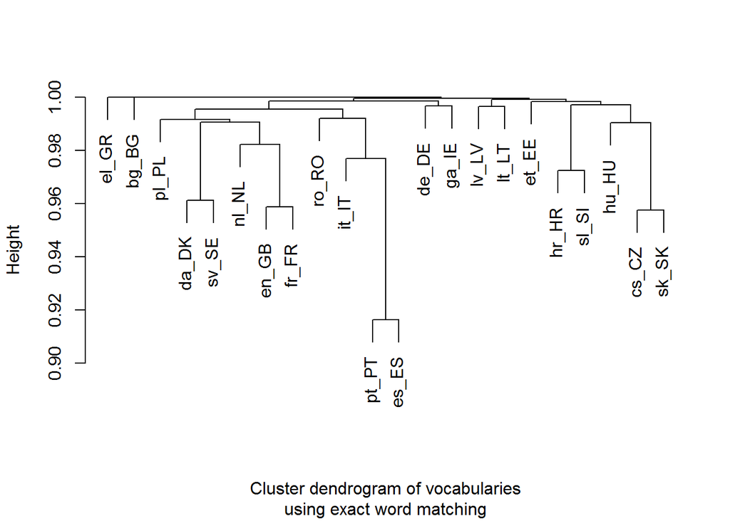

```r
mat <- as.matrix(mDist)
#mat[lower.tri(mat)] <- ''
knitr::kable(mat[,2:8], caption = "Vocabularies distance using exact word matching")
```

Vocabularies distance using exact word matching

|  | hr_HR | cs_CZ | da_DK | nl_NL | en_GB | et_EE | fr_FR |
| --- | --- | --- | --- | --- | --- | --- | --- |
| bg_BG | 1.0000000 | 1.0000000 | 1.0000000 | 1.0000000 | 1.0000000 | 1.0000000 | 1.0000000 |
| hr_HR | 0.0000000 | 0.9950517 | 0.9957717 | 0.9973061 | 0.9971163 | 0.9971855 | 0.9984846 |
| cs_CZ | 0.9950517 | 0.0000000 | 0.9914238 | 0.9935128 | 0.9908230 | 0.9984447 | 0.9950095 |
| da_DK | 0.9957717 | 0.9914238 | 0.0000000 | 0.9807028 | 0.9729823 | 0.9959698 | 0.9870562 |
| nl_NL | 0.9973061 | 0.9935128 | 0.9807028 | 0.0000000 | 0.9713650 | 0.9959729 | 0.9822716 |
| en_GB | 0.9971163 | 0.9908230 | 0.9729823 | 0.9713650 | 0.0000000 | 0.9970013 | 0.9588505 |
| et_EE | 0.9971855 | 0.9984447 | 0.9959698 | 0.9959729 | 0.9970013 | 0.0000000 | 0.9976601 |
| fr_FR | 0.9984846 | 0.9950095 | 0.9870562 | 0.9822716 | 0.9588505 | 0.9976601 | 0.0000000 |
| de_DE | 0.9996456 | 0.9957151 | 0.9934287 | 0.9930614 | 0.9896744 | 0.9996248 | 0.9971923 |
| el_GR | 1.0000000 | 1.0000000 | 1.0000000 | 1.0000000 | 1.0000000 | 1.0000000 | 1.0000000 |
| hu_HU | 0.9971798 | 0.9904044 | 0.9921764 | 0.9942315 | 0.9885161 | 0.9980162 | 0.9945140 |
| ga_IE | 0.9993676 | 0.9968137 | 0.9945974 | 0.9964418 | 0.9865805 | 0.9993833 | 0.9963624 |
| it_IT | 0.9980078 | 0.9961185 | 0.9919548 | 0.9909306 | 0.9824334 | 0.9984985 | 0.9856155 |
| lv_LV | 0.9983660 | 0.9987971 | 0.9982343 | 0.9988675 | 0.9986451 | 0.9989126 | 0.9990744 |
| lt_LT | 0.9960027 | 0.9981917 | 0.9977963 | 0.9985107 | 0.9975549 | 0.9987476 | 0.9989904 |
| pl_PL | 0.9946607 | 0.9858495 | 0.9887899 | 0.9891335 | 0.9831523 | 0.9974506 | 0.9916465 |
| pt_PT | 0.9983159 | 0.9967711 | 0.9941241 | 0.9950583 | 0.9792359 | 0.9991050 | 0.9914953 |
| ro_RO | 0.9966747 | 0.9974355 | 0.9939589 | 0.9944476 | 0.9797630 | 0.9986032 | 0.9923275 |
| sk_SK | 0.9935443 | 0.9575697 | 0.9932409 | 0.9949912 | 0.9932135 | 0.9979164 | 0.9965935 |
| sl_SI | 0.9725991 | 0.9917212 | 0.9927850 | 0.9955910 | 0.9937559 | 0.9974340 | 0.9973319 |
| es_ES | 0.9974613 | 0.9975560 | 0.9945903 | 0.9943269 | 0.9842237 | 0.9982971 | 0.9879393 |
| sv_SE | 0.9951708 | 0.9941117 | 0.9611890 | 0.9866061 | 0.9726686 | 0.9953781 | 0.9907153 |

```r
knitr::kable(mat[,9:15], caption = "Vocabularies distance using exact word matching cntd")
```

Vocabularies distance using exact word matching cntd

|  | de_DE | el_GR | hu_HU | ga_IE | it_IT | lv_LV | lt_LT |
| --- | --- | --- | --- | --- | --- | --- | --- |
| bg_BG | 1.0000000 | 1.0000000 | 1.0000000 | 1.0000000 | 1.0000000 | 1.0000000 | 1.0000000 |
| hr_HR | 0.9996456 | 1.0000000 | 0.9971798 | 0.9993676 | 0.9980078 | 0.9983660 | 0.9960027 |
| cs_CZ | 0.9957151 | 1.0000000 | 0.9904044 | 0.9968137 | 0.9961185 | 0.9987971 | 0.9981917 |
| da_DK | 0.9934287 | 1.0000000 | 0.9921764 | 0.9945974 | 0.9919548 | 0.9982343 | 0.9977963 |
| nl_NL | 0.9930614 | 1.0000000 | 0.9942315 | 0.9964418 | 0.9909306 | 0.9988675 | 0.9985107 |
| en_GB | 0.9896744 | 1.0000000 | 0.9885161 | 0.9865805 | 0.9824334 | 0.9986451 | 0.9975549 |
| et_EE | 0.9996248 | 1.0000000 | 0.9980162 | 0.9993833 | 0.9984985 | 0.9989126 | 0.9987476 |
| fr_FR | 0.9971923 | 1.0000000 | 0.9945140 | 0.9963624 | 0.9856155 | 0.9990744 | 0.9989904 |
| de_DE | 0.0000000 | 1.0000000 | 0.9951991 | 0.9969049 | 0.9977772 | 0.9996399 | 0.9990719 |
| el_GR | 1.0000000 | 0.0000000 | 0.9999342 | 1.0000000 | 1.0000000 | 1.0000000 | 1.0000000 |
| hu_HU | 0.9951991 | 0.9999342 | 0.0000000 | 0.9962753 | 0.9946500 | 0.9989956 | 0.9976632 |
| ga_IE | 0.9969049 | 1.0000000 | 0.9962753 | 0.0000000 | 0.9973169 | 0.9996068 | 0.9991826 |
| it_IT | 0.9977772 | 1.0000000 | 0.9946500 | 0.9973169 | 0.0000000 | 0.9990711 | 0.9980258 |
| lv_LV | 0.9996399 | 1.0000000 | 0.9989956 | 0.9996068 | 0.9990711 | 0.0000000 | 0.9966034 |
| lt_LT | 0.9990719 | 1.0000000 | 0.9976632 | 0.9991826 | 0.9980258 | 0.9966034 | 0.0000000 |
| pl_PL | 0.9956825 | 1.0000000 | 0.9923224 | 0.9958644 | 0.9896010 | 0.9987256 | 0.9974988 |
| pt_PT | 0.9960293 | 1.0000000 | 0.9947908 | 0.9955037 | 0.9770610 | 0.9993165 | 0.9978201 |
| ro_RO | 0.9968151 | 1.0000000 | 0.9962574 | 0.9976936 | 0.9920662 | 0.9994759 | 0.9987267 |
| sk_SK | 0.9978439 | 1.0000000 | 0.9901538 | 0.9979675 | 0.9960454 | 0.9987204 | 0.9975647 |
| sl_SI | 0.9976295 | 1.0000000 | 0.9957264 | 0.9972250 | 0.9978785 | 0.9991776 | 0.9991497 |
| es_ES | 0.9986264 | 1.0000000 | 0.9964403 | 0.9978043 | 0.9713364 | 0.9988941 | 0.9974989 |
| sv_SE | 0.9920841 | 1.0000000 | 0.9914064 | 0.9963819 | 0.9931007 | 0.9986894 | 0.9972757 |

```r
knitr::kable(mat[,16:22], caption = "Vocabularies distance using exact word matching cntd")
```

Vocabularies distance using exact word matching cntd

|  | pl_PL | pt_PT | ro_RO | sk_SK | sl_SI | es_ES | sv_SE |
| --- | --- | --- | --- | --- | --- | --- | --- |
| bg_BG | 1.0000000 | 1.0000000 | 1.0000000 | 1.0000000 | 1.0000000 | 1.0000000 | 1.0000000 |
| hr_HR | 0.9946607 | 0.9983159 | 0.9966747 | 0.9935443 | 0.9725991 | 0.9974613 | 0.9951708 |
| cs_CZ | 0.9858495 | 0.9967711 | 0.9974355 | 0.9575697 | 0.9917212 | 0.9975560 | 0.9941117 |
| da_DK | 0.9887899 | 0.9941241 | 0.9939589 | 0.9932409 | 0.9927850 | 0.9945903 | 0.9611890 |
| nl_NL | 0.9891335 | 0.9950583 | 0.9944476 | 0.9949912 | 0.9955910 | 0.9943269 | 0.9866061 |
| en_GB | 0.9831523 | 0.9792359 | 0.9797630 | 0.9932135 | 0.9937559 | 0.9842237 | 0.9726686 |
| et_EE | 0.9974506 | 0.9991050 | 0.9986032 | 0.9979164 | 0.9974340 | 0.9982971 | 0.9953781 |
| fr_FR | 0.9916465 | 0.9914953 | 0.9923275 | 0.9965935 | 0.9973319 | 0.9879393 | 0.9907153 |
| de_DE | 0.9956825 | 0.9960293 | 0.9968151 | 0.9978439 | 0.9976295 | 0.9986264 | 0.9920841 |
| el_GR | 1.0000000 | 1.0000000 | 1.0000000 | 1.0000000 | 1.0000000 | 1.0000000 | 1.0000000 |
| hu_HU | 0.9923224 | 0.9947908 | 0.9962574 | 0.9901538 | 0.9957264 | 0.9964403 | 0.9914064 |
| ga_IE | 0.9958644 | 0.9955037 | 0.9976936 | 0.9979675 | 0.9972250 | 0.9978043 | 0.9963819 |
| it_IT | 0.9896010 | 0.9770610 | 0.9920662 | 0.9960454 | 0.9978785 | 0.9713364 | 0.9931007 |
| lv_LV | 0.9987256 | 0.9993165 | 0.9994759 | 0.9987204 | 0.9991776 | 0.9988941 | 0.9986894 |
| lt_LT | 0.9974988 | 0.9978201 | 0.9987267 | 0.9975647 | 0.9991497 | 0.9974989 | 0.9972757 |
| pl_PL | 0.0000000 | 0.9944366 | 0.9955553 | 0.9909898 | 0.9923790 | 0.9943816 | 0.9912803 |
| pt_PT | 0.9944366 | 0.0000000 | 0.9884227 | 0.9967671 | 0.9974409 | 0.9163081 | 0.9929131 |
| ro_RO | 0.9955553 | 0.9884227 | 0.0000000 | 0.9971572 | 0.9967697 | 0.9902295 | 0.9899504 |
| sk_SK | 0.9909898 | 0.9967671 | 0.9971572 | 0.0000000 | 0.9930935 | 0.9965448 | 0.9938947 |
| sl_SI | 0.9923790 | 0.9974409 | 0.9967697 | 0.9930935 | 0.0000000 | 0.9978718 | 0.9935822 |
| es_ES | 0.9943816 | 0.9163081 | 0.9902295 | 0.9965448 | 0.9978718 | 0.0000000 | 0.9934191 |
| sv_SE | 0.9912803 | 0.9929131 | 0.9899504 | 0.9938947 | 0.9935822 | 0.9934191 | 0.0000000 |

## Clustering vocabularies using approximate word matching

```r
# using Levenshtein distance
vocab_1 <- c("leia","uhura", "banan")
vocab_2 <- c("ripley","leela","scully","trinity", 'banaan', 'ananas')
vocab_3 <- c(NA)

ind <- stringdist::amatch(x = vocab_1,
                          table = vocab_2,
                          method = 'lv',
                          maxDist = 3)
ind
```

```
## [1]  2 NA  5
```

```r
res_1 = vocab_1[!is.na(vocab_2[ind])]
res_2 = vocab_2[ind][!is.na(vocab_2[ind])]

1 - length(union(res_1, res_2))/ length(union(vocab_1, vocab_2))
```

```
## [1] 0.5555556
```

[figure not shown]

## kmed

```r
require(kmed)
result <- fastkmed(mDist, ncluster = 5, iterate = 50)
```